# STAT 327 Homework 3

We’ll grade your homework by

- opening your “hw3.Rmd” file in RStudio
- clicking “Knit HTML”
- reading the HTML output
- reading your “hw3.Rmd”

You should write R code anywhere you see an empty R code chunk. You should write English text anywhere you see “…”; please surround it with doubled asterisks (`**...**`) so that it will show up as boldface and be easy for us to find.

Include reasonable labels (titles, axis labels, legends, etc.) with each of your graphs.

Name: David Fastovich

Email: fastovich@wisc.edu

We’ll use data on housing values in suburbs of Boston. They are in an R package called “MASS.” (An R package is a collection of code, data, and documentation. “MASS” refers to the book “Modern Applied Statistics with S.” R developed from the earlier language, S.) The MASS package comes with the default R installation, so it’s already on your computer. However, it’s not loaded into your R session by default. So we’ll load it via the `require()` command (there’s nothing for you to do here):

```r
require("MASS")
```

Run `?Boston` (outside this R Markdown document) to read the help page for the `Boston` data frame.

Convert the `chas` variable to a factor with labels “off” and “on” (referring to the Charles river).

```r
bos <- Boston
bos$chas <- factor(bos$chas, levels = c("0", "1"), labels = c("off", "on"))
```

How many rows are in the Boston data frame? How many columns?

```r
str(bos)
```

```
## 'data.frame':    506 obs. of  14 variables:
##  $ crim   : num  0.00632 0.02731 0.02729 0.03237 0.06905 ...
##  $ zn     : num  18 0 0 0 0 0 12.5 12.5 12.5 12.5 ...
##  $ indus  : num  2.31 7.07 7.07 2.18 2.18 2.18 7.87 7.87 7.87 7.87 ...
##  $ chas   : Factor w/ 2 levels "off","on": 1 1 1 1 1 1 1 1 1 1 ...
##  $ nox    : num  0.538 0.469 0.469 0.458 0.458 0.458 0.524 0.524 0.524 0.524 ...
##  $ rm     : num  6.58 6.42 7.18 7 7.15 ...
##  $ age    : num  65.2 78.9 61.1 45.8 54.2 58.7 66.6 96.1 100 85.9 ...
##  $ dis    : num  4.09 4.97 4.97 6.06 6.06 ...
##  $ rad    : int  1 2 2 3 3 3 5 5 5 5 ...
##  $ tax    : num  296 242 242 222 222 222 311 311 311 311 ...
##  $ ptratio: num  15.3 17.8 17.8 18.7 18.7 18.7 15.2 15.2 15.2 15.2 ...
##  $ black  : num  397 397 393 395 397 ...
##  $ lstat  : num  4.98 9.14 4.03 2.94 5.33 ...
##  $ medv   : num  24 21.6 34.7 33.4 36.2 28.7 22.9 27.1 16.5 18.9 ...
```

**There are 506 rows and 14 columns.**

What does a row represent?

**A row represents a neighborhood.**

What does a column represent?

**Column represents a series of variables that were used to predict the median value (last column) of the house of interest.**

Make a density plot (with rug) of tax rates.

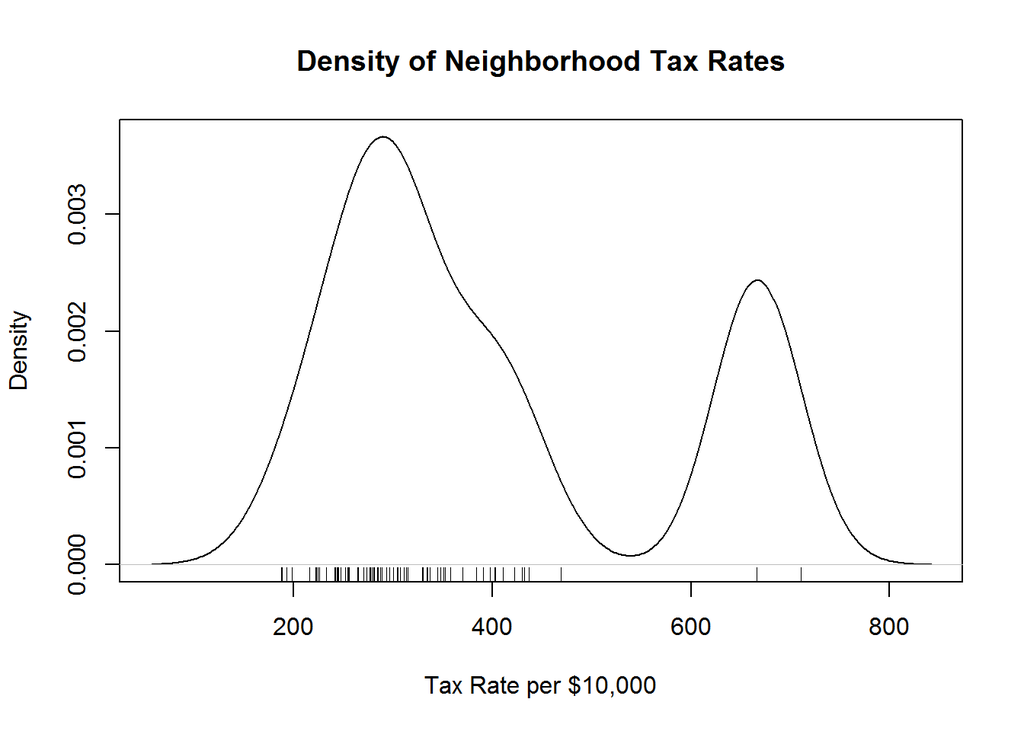

```r
plot(density(bos$tax),
     main = "Density of Neighborhood Tax Rates",
     xlab = "Tax Rate per $10,000")
rug(bos$tax)
```

Describe the shape of the distribution of tax rates.

**The distribution is bimodal.**

Note that the distribution shape doesn’t make sense in light of the rug representation of the data. Make a histogram of the tax rates.

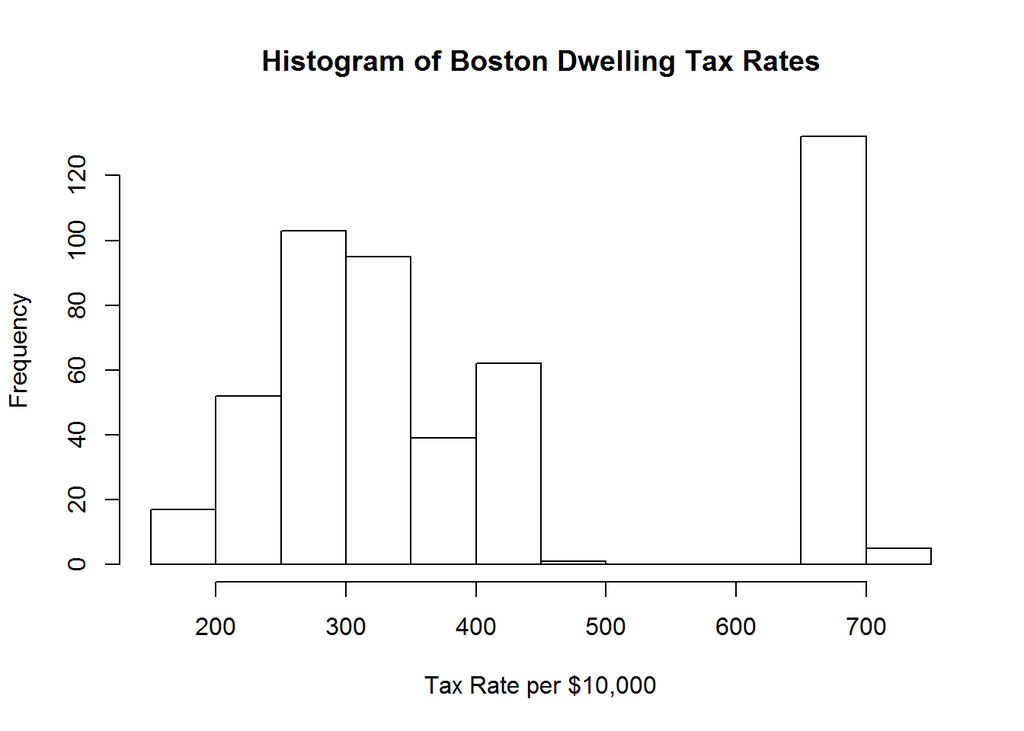

```r
hist(bos$tax,
     main = "Histogram of Boston Dwelling Tax Rates",
     xlab = "Tax Rate per $10,000")
```

Why is the second peak of the density plot so large? In what way is the rug representation of the data inadequate? Write a line or two of code to figure it out, and then explain it.

```r
tax.table <- table(bos$tax)
tax.table[names(tax.table) > 600]
```

```
##
## 666 711
## 132   5
```

**The second peak in the density plot is large because there are 132 houses that have the same tax rate and 137 houses that have a tax rate greater than 600. This is likely because after a certain value the tax rate becomes constant. Therefore, rug is inadequate because it does not show the amount of houses that share this same tax rate.**

Make a barplot of “chas”.

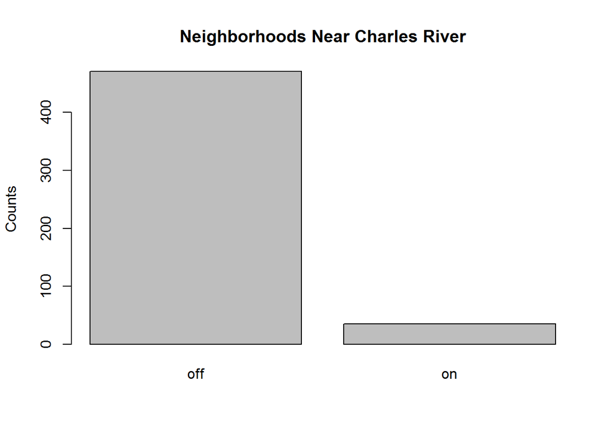

```r
barplot(table(bos$chas),
        main = "Neighborhoods Near Charles River",
        ylab = "Counts")
```

How many neighborhoods are on the Charles river?

```r
table(bos$chas)
```

```
##
## off  on
## 471  35
```

Make a single graph consisting of three plots:

- a scatterplot of “nox” on the y-axis vs. “dis” on the x-axis
- a (vertical) boxplot of “nox” left of the scatterplot’s y-axis
- a (horizontal) boxplot of “dis” below the scatterplot’s x-axis

Hint: use `layout()` with a 4x4 matrix, using the top-right 3x3 corner for the scatterplot, leaving the bottom-left 1x1 corner blank, and using the other parts for the boxplots.

(An optional challenge, worth 0 extra credit points: remove the axis and plot border from each boxplot.)

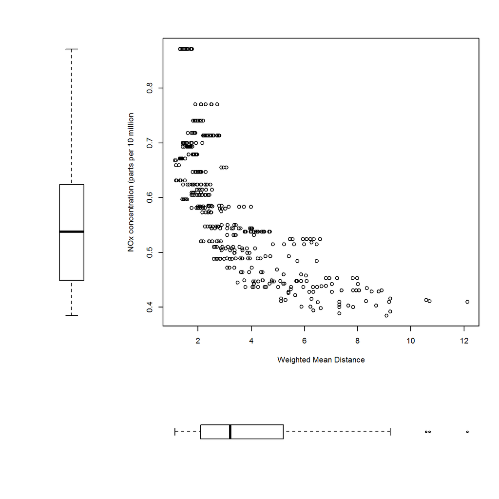

```r
m <- matrix(data = c(2, 1, 1, 1, 2, 1, 1, 1, 2, 1, 1, 1, 0, 3, 3, 3),
           nrow = 4,
           ncol = 4,
           byrow = TRUE)
layout(m)
plot(x = bos$dis, y = bos$nox,
     xlab = "Weighted Mean Distance",
     ylab = "NOx concentration (parts per 10 million")
boxplot(bos$nox, frame = FALSE, axes = FALSE)
boxplot(bos$dis, horizontal = TRUE, frame = FALSE, axes = FALSE)
```

```r
layout(1)
```

Look into the highest-crime neighborhood by making a single graph of one column of three rows:

- Find the row number, r, of the neighborhood with the highest “crim”.
- Make a density plot of “crim”. Include a rug to show the data.
- Add a red circle at (x, y) = (max crime rate, 0) to make this maximum crime rate stand out.
- Make a density plot with rug of “medv”, adding a red circle at (x, y) = (medv[r], 0) to see what medv corresponds to the highest crime rate.
- Repeat the last step for “ptratio”.

```r
bos[which.max(bos$crim), ]
```

```
##        crim zn indus chas   nox    rm  age    dis rad tax ptratio black
## 381 88.9762  0  18.1  off 0.671 6.968 91.9 1.4165  24 666    20.2 396.9
##     lstat medv
## 381 17.21 10.4
```

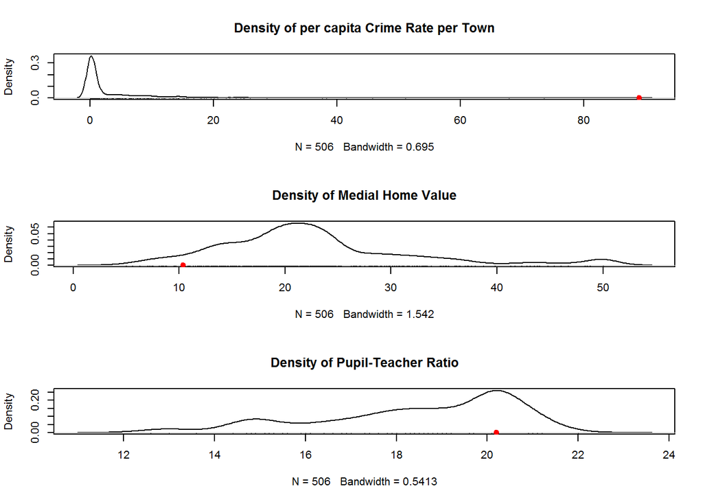

```r
par(mfrow = c(3,1))
plot(density(bos$crim), main = "Density of per capita Crime Rate per Town")
rug(bos$crim)
points(bos$crim[which.max(bos$crim)], 0, col = "red", pch = 19)
plot(density(bos$medv), main = "Density of Medial Home Value")
rug(bos$medv)
points(bos$medv[which.max(bos$crim)], 0, col = "red", pch = 19)
plot(density(bos$ptratio), main = "Density of Pupil-Teacher Ratio")
rug(bos$ptratio)
points(bos$ptratio[which.max(bos$crim)], 0, col = "red", pch = 19)
```

What do you notice about the ptratio and medv for the highest-crime neighborhood?

**The highest-crime neighborhood has one of the largest pupil to teacher ratios with some of the lowest median home values.**